# Project Summary

UNC EPID 722 – Sydney Allison Jones & Ann Von Holle

April 26, 2016

# Topics

- Data generation
- Data analysis
- Data analysis follow-up

# Data generation

- Generate time to event using National Ambulatory Medical Care Survey [NAMCS](http://www.cdc.gov.libproxy.lib.unc.edu/nchs/ahcd/about_ahcd.htm) data:
- Introduce
  - Non-positivity
    - Exclude persons with hypertension who were not treated
  - Confounding
  - Treatment effect heterogeneity
    - Low-potency statins had no effect
- Subset to a 10% random sample of the non-users
  - To make data set a more manageable size.

# Generate time to event for CVD hospitalization and all-cause mortality

- Time to event will follow a Weibull distribution
- T $\sim$ Weibull($\lambda, k$)
  - scale = $\lambda$
  - shape = $k$
    - Weibull density function: $f(t;\lambda, k) = k \lambda t^{k-1} e^{-\lambda t^k}$
    - Exponential density function: $f(x; \lambda) = \lambda e^{-\lambda t}$
      - Equivalent to Weibull using shape = 1.
- Censoring follows an exponential distribution with $\lambda$ = 0.005

# CVD hospitalization

# All-cause mortality

# Data generation key points

- *True* hazard ratio = 0.801
  - log(HR) = -0.222; standard error = 0.093.
- **No** variables associated with drop out
- **No** variables associated with missing data in effect model
- **No** product term between any variable and time to event
  - proportional hazards assumption should hold

# Data analysis

# Our analyses on entire class data set

HR and 95% CI (treated vs not treated)

|  |  | Method for missing |  |  |
| --- | --- | --- | --- | --- |
| Confounding + Selection bias handling |  | Omit BP | Impute | Missing weight |
| Crude |  | 1.34 (1.09, 1.65) | 1.34 (1.09, 1.65) | 1.31 (1.05, 1.64) |
| IPTW |  | 0.78 (0.54, 1.12) | 0.78 (0.54, 1.12) | 0.92 (0.62, 1.37) |
| IPTW + censor weight |  | 0.78 (0.54, 1.12) | 0.78 (0.54, 1.12) | 0.92 (0.62, 1.37) |

- Covariates for:
  - IPTW model: age, male, diabetes, white, obese, smoke, hyplipid [sbp and dbp when using MI or missing weights]
  - Censoring weight model: age, male, diabetes, white, obese, smoke, hyplipid [sbp and dbp when using MI or missing weights]
  - Missing weight model: newuser, age, male, diabetes, white, obese, smoke, hyplipid, htn, event

# Our survival curves by treatment status and data set type

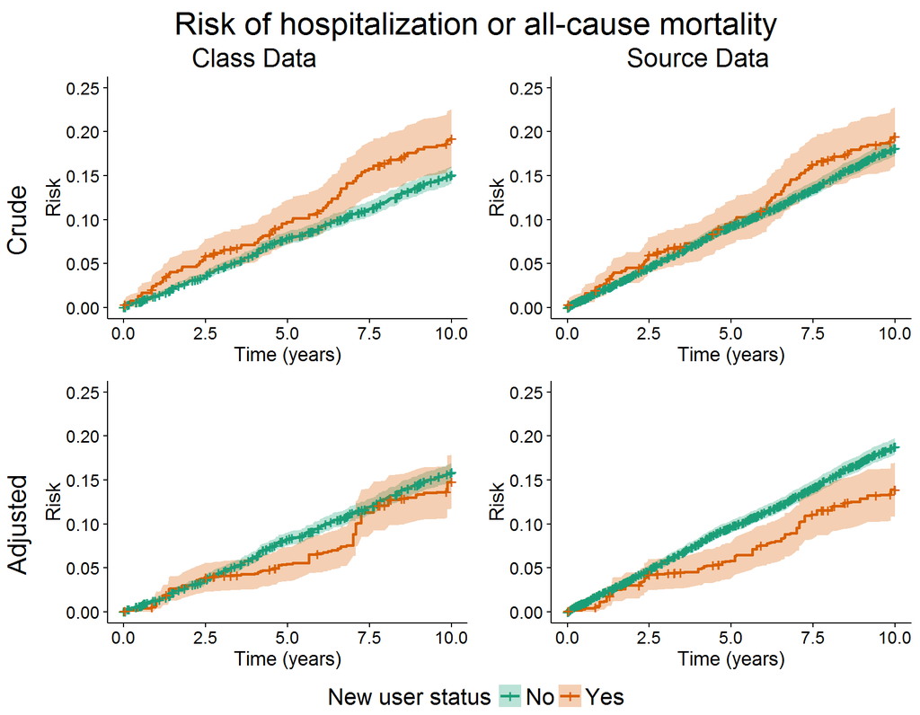

# Summary of group analyses

- Approaches used
  - Missing data: inverse probability weighting (5 groups) or multiple imputation (2 groups)
  - Censoring: time-varying inverse probability weighting (7 groups)
  - Wide range of variables included in censoring weights
  - Confounding: inverse probability weighting (7 groups)
  - Most groups included: age, diabetes, DBP, SBP, obese, race, sex, and smoking
  - No groups included HTN in the confounding weight model
- Results presented:
  - Hazard ratio (5 groups)
  - Risk difference (2 groups)

# Class group results

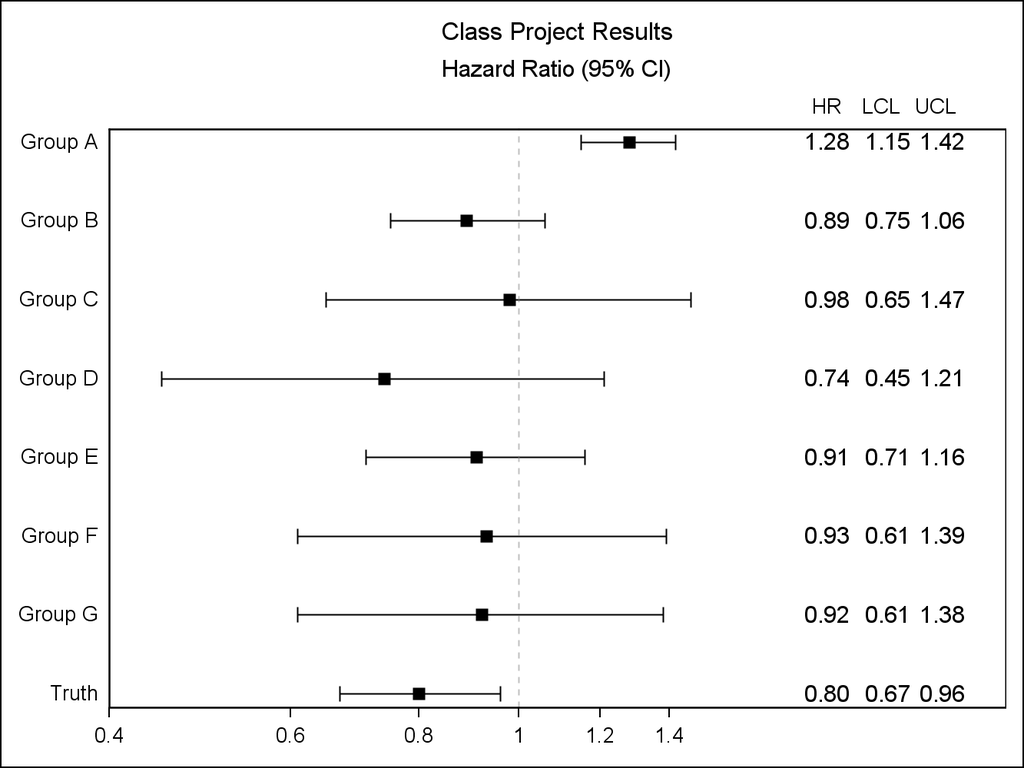

# Class group example: Table 2

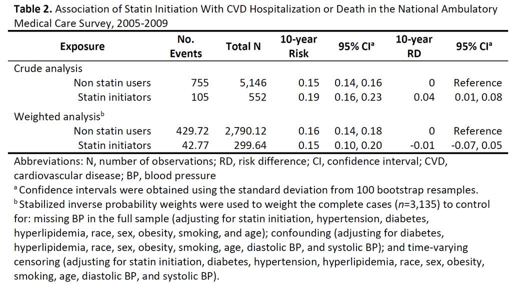

# Class group example: Figure

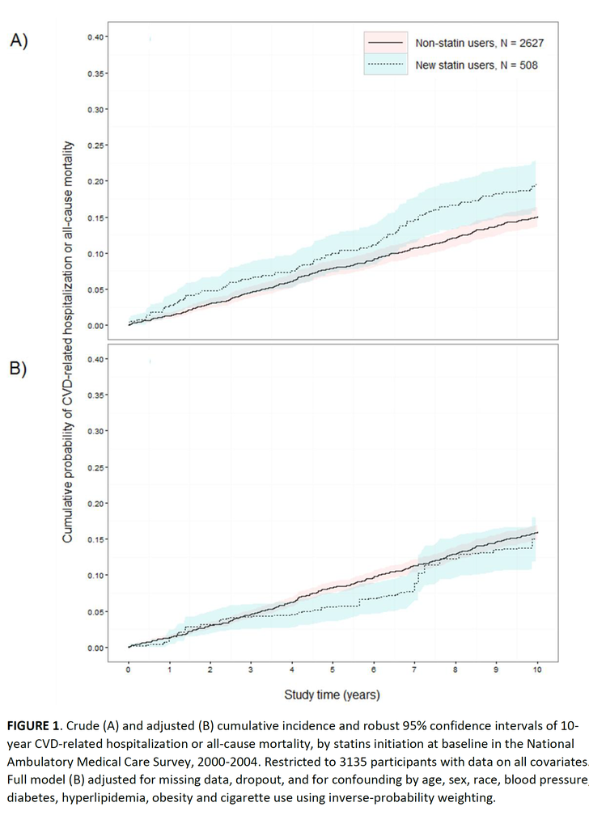

# A few points given the model generating the data

# Censoring weights don’t (shouldn’t) matter

HR and 95% CI (treated vs not treated)

|  |  | Method for missing |  |  |
| --- | --- | --- | --- | --- |
| Confounding + Selection bias handling |  | Omit BP | Impute | Missing weight |
| Crude |  | 1.34 (1.09, 1.65) | 1.34 (1.09, 1.65) | 1.31 (1.05, 1.64) |
| IPTW |  | 0.78 (0.54, 1.12) | 0.78 (0.54, 1.12) | 0.92 (0.62, 1.37) |
| IPTW + censor weight |  | 0.78 (0.54, 1.12) | 0.78 (0.54, 1.12) | 0.92 (0.62, 1.37) |

# Accounting for missing data shouldn’t matter

HR and 95% CI (treated vs not treated)

|  |  | Method for missing |  |  |
| --- | --- | --- | --- | --- |
| Confounding + Selection bias handling |  | Omit BP | Impute | Missing weight |
| Crude |  | 1.34 (1.09, 1.65) | 1.34 (1.09, 1.65) | 1.31 (1.05, 1.64) |
| IPTW |  | 0.78 (0.54, 1.12) | 0.78 (0.54, 1.12) | 0.92 (0.62, 1.37) |
| IPTW + censor weight |  | 0.78 (0.54, 1.12) | 0.78 (0.54, 1.12) | 0.92 (0.62, 1.37) |

# Why are there differences in treatment effect when using missing weights?

HR and 95% CI (treated vs not treated)

|  |  | Method for missing |  |  |
| --- | --- | --- | --- | --- |
| Confounding + Selection bias handling |  | Omit BP | Impute | Missing weight |
| Crude |  | 1.34 (1.09, 1.65) | 1.34 (1.09, 1.65) | 1.31 (1.05, 1.64) |
| IPTW |  | 0.78 (0.54, 1.12) | 0.78 (0.54, 1.12) | 0.92 (0.62, 1.37) |
| IPTW + censor weight |  | 0.78 (0.54, 1.12) | 0.78 (0.54, 1.12) | 0.92 (0.62, 1.37) |

# What’s happening with the missing weights?

- People with adverse conditions (hypertension, etc..) are more likely to be a complete case.

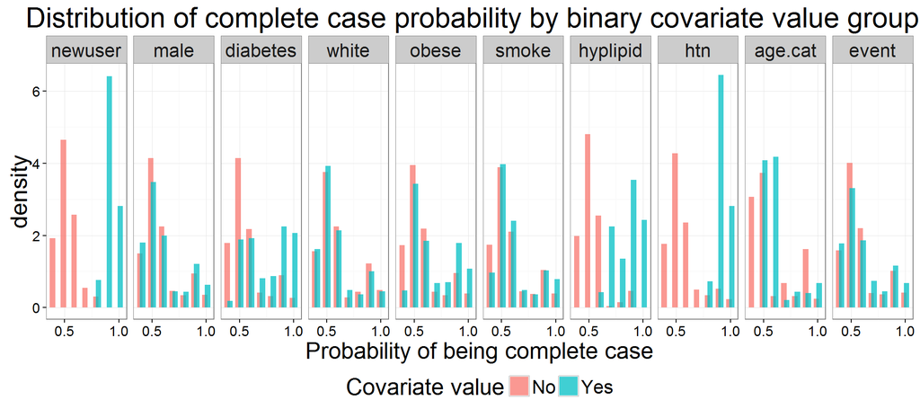

# What’s happening with the missing weights?

- People with hypertension more likely to benefit from treatment than people with no hypertension.

HR and 95% CI (treated vs not treated)

|  |  | Method for missing |
| --- | --- | --- |
| Confounding + Selection bias handling |  | Omit BP |
| HTN=1 subset (Source data) |  |  |
| Crude |  | 0.75 (0.57, 0.98) |
| IPTW |  | 0.60 (0.42, 0.87) |
| IPTW + censor weight |  | 0.60 (0.41, 0.86) |

# Non-Positivity

- Several of you noticed the non-positivity
- What can you do about it?

# Non-Positivity

**What is the impact on our inferences?**

HR and 95% CI (treated vs not treated)

|  |  | Method for missing |  |  |
| --- | --- | --- | --- | --- |
| Confounding + Selection bias handling |  | Omit BP | Impute | Missing weight |
| Class data |  |  |  |  |
| Crude |  | 1.34 (1.09, 1.65) | 1.34 (1.09, 1.65) | 1.31 (1.05, 1.64) |
| IPTW |  | 0.78 (0.54, 1.12) | 0.78 (0.54, 1.12) | 0.92 (0.62, 1.37) |
| IPTW + censor weight |  | 0.78 (0.54, 1.12) | 0.78 (0.54, 1.12) | 0.92 (0.62, 1.37) |
| HTN=0 subset |  |  |  |  |
| Crude |  | 1.19 (0.88, 1.6) | 1.19 (0.88, 1.6) | 1.05 (0.75, 1.48) |
| IPTW |  | 0.72 (0.43, 1.2) | 0.72 (0.43, 1.2) | 0.71 (0.39, 1.27) |
| IPTW + censor weight |  | 0.72 (0.43, 1.2) | 0.72 (0.43, 1.2) | 0.71 (0.39, 1.27) |
| Source data |  |  |  |  |
| Crude |  | 1.09 (0.89, 1.33) | 1.09 (0.89, 1.33) | 1.06 (0.86, 1.32) |
| IPTW |  | 0.72 (0.52, 0.99) | 0.72 (0.52, 0.99) | 0.74 (0.53, 1.03) |
| IPTW + censor weight |  | 0.72 (0.52, 0.99) | 0.72 (0.52, 0.99) | 0.74 (0.54, 1.03) |

# References

1. Seaman S, White I. Inverse Probability Weighting with Missing Predictors of Treatment Assignment or Missingness. *Communications in Statistics - Theory and Methods* [electronic article]. 2014;43(16):3499–3515. (http://www.tandfonline.com/doi/abs/10.1080/03610926.2012.700371)

2. Seaman SR, White IR, Copas AJ, et al. Combining Multiple Imputation and Inverse-Probability Weighting. *Biometrics* [electronic article]. 2012;68(1):129–137. (http://doi.wiley.com/10.1111/j.1541-0420.2011.01666.x)

3. Seaman SR, White IR. Review of inverse probability weighting for dealing with missing data. *Statistical Methods in Medical Research* [electronic article]. 2013;22(3):278–295. (http://smm.sagepub.com/cgi/doi/10.1177/0962280210395740)